# Prenatal MRI - Animals

David Pagliaccio

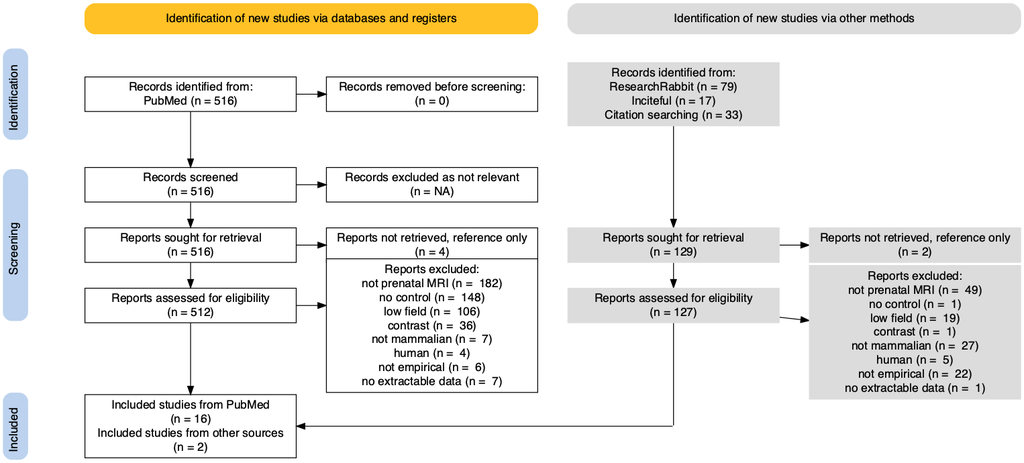

FigureS1

## Results

18 publications examining prenatal MRI exposure among rodents were meta-analyzed. This included including k=81 outcomes assessed across n=649 unexposed dams, n=622 exposed dams, n=3273 unexposed offspring, n=3565 exposed offspring.

A multi-level model clustering effect sizes for multiple outcomes within publication found no evidence for an effect of prenatal MRI exposure (SMD=0.17, 95%CI=-0.19,0.54, t=0.94, p=0.35; Figure S2), i.e., a non-significant and small effect size (0.17SD difference in means) in the direction of better outcomes for the exposed group.

There was substantial heterogeneity in effect size (I2=100%; between-studies τ2= 0.34 95%CI=0.06, 1.02; within-studies τ2= 0.88 95%CI=0.61, 1.31).

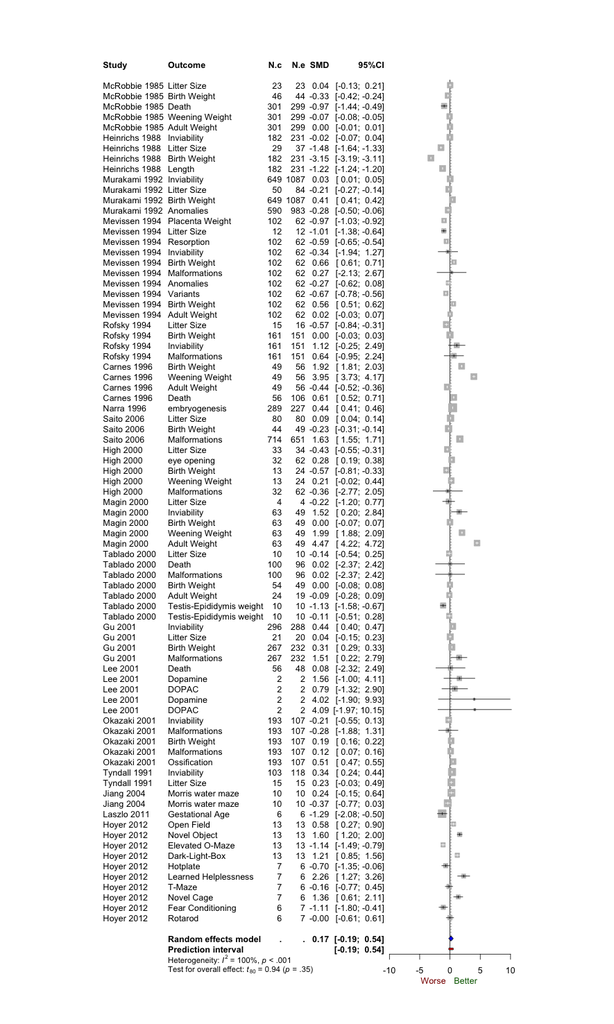

FigureS2

We do not see clear evidence of publication bias; the effect sizes were not significantly related to the size of their standard error (Figure S3; Egger’s test: t(79) = -1.4, p=0.16).

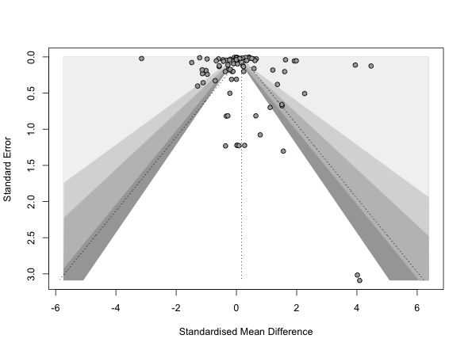

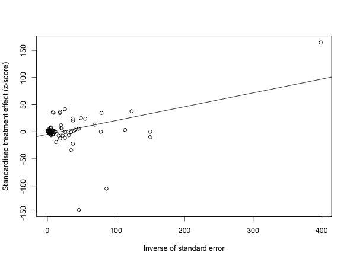

Examining influence statistics and omitting n=12 effects with high influence (DFFITS>0.33) did not change the results meaningfully (SMD=-0.12, 95%CI=-0.39,0.14, t=-0.94, p=0.35.

In a meta-regression, only the age at which outcomes were assessed was a trend-level significant predictor (b=-0.76, 95%CI=-1.38,-0.14, t(75)=-2.43, p=0.02); ns. for publication year, exposure length, field strength, control condition); such that perinatal outcomes had a SMD closer to zero compared to higher SMD among adult outcomes (adult outcomes k=9; SMD=0.72, 95%CI=-0.15,1.58, t=1.91, p=0.09; perinatal outcomes k=16; SMD=-0.02, 95%CI=-0.38,0.35, t=-0.11, p=0.92; Figure S4).

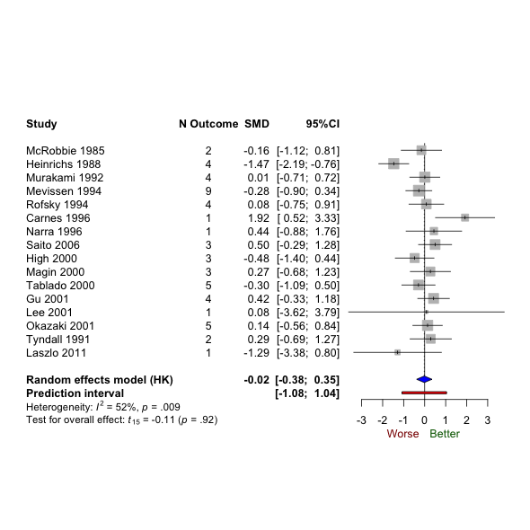

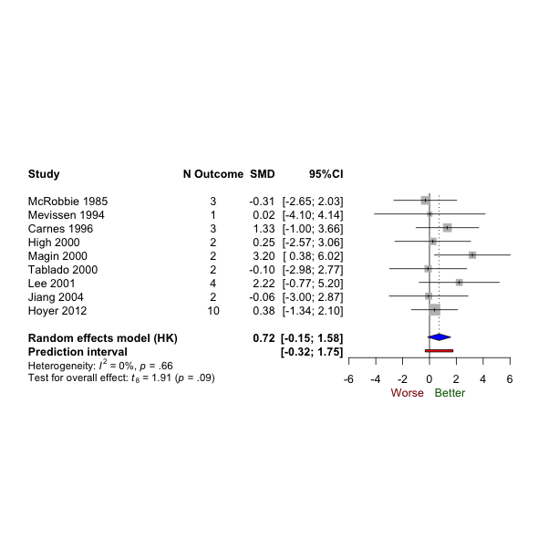

Similarly, no significant meta-analytic effects were observed when focusing on the four most commonly reported outcomes: birth weight (n = 13, SMD=-0.07, 95%CI=-0.8,0.66), litter size (n=11, SMD=-0.34, 95%CI=-0.69,0.02), fetal inviability (n=8, SMD=0.19, 95%CI=-0.13,0.5), or physical malformations (n=8, SMD=0.76, 95%CI=-0.1,1.62).